# L3 VaR and ES

Week 7-8

# Gaussian VaR Example

- Step 1: Import Daily EW Portfolio Returns we used in Lecture 2.
  - Load the data using load(“crsp.ew.RData”)
  - Filter data to year 2013
  - Assuming we placed $ 1 million at the start of the period into the portfolio

```r
setwd("C:/Users/siche/Documents/teaching/Introduction to Financial Data Analysis/L3/")
load("crsp.ew.RData")
head(crsp.ew)
```

```
##         date       ew    yymm          ret   ew.all
## 1 2010-01-04 1.019541 2010-01 0.0195410781 1.019541
## 2 2010-01-05 1.031180 2010-01 0.0114163006 1.031180
## 3 2010-01-06 1.042768 2010-01 0.0112376086 1.042768
## 4 2010-01-07 1.052241 2010-01 0.0090844033 1.052241
## 5 2010-01-08 1.060328 2010-01 0.0076855758 1.060328
## 6 2010-01-11 1.061044 2010-01 0.0006743764 1.061044
```

```r
crsp.ew = crsp.ew[which(substr(crsp.ew$date,1,4)=='2013'),
                  c("date","ret")]
head(crsp.ew)
```

```
##           date         ret
## 755 2013-01-02 0.022294022
## 756 2013-01-03 0.017951026
## 757 2013-01-04 0.021527329
## 758 2013-01-07 0.014202149
## 759 2013-01-08 0.004382363
## 760 2013-01-09 0.009990037
```

```r
invest = 1e6
```

- Step 2: Calculate Mean and Standard Deviation of Historical Daily Portfolio Returns

```r
mu = mean(crsp.ew$ret,na.rm=T)
sigma = sd(crsp.ew$ret,na.rm = T)
print(paste0("mu = ", mu))
```

```
## [1] "mu = 0.00163303157814819"
```

```r
print(paste0("sigma = ", sigma))
```

```
## [1] "sigma = 0.0120990503250133"
```

- Step 3: Calculate 1% and 5% VaR
  - $VaR_{\alpha}=-(\sigma Z_{\alpha}+\mu)\times I$
  - $Z_{\alpha}$ is calculated using the qnorm($\alpha$) command, which returns the inverse cumulative density function.

```r
q1 = qnorm(0.01)
q5 = qnorm(0.05)
var.q1 = -(sigma * q1 + mu) * invest
var.q5 = -(sigma * q5 + mu) * invest
print(paste0("VaR(0.01) = ", round(var.q1,2)))
```

```
## [1] "VaR(0.01) = 26513.57"
```

```r
print(paste0("VaR(0.05) = ", round(var.q5,2)))
```

```
## [1] "VaR(0.05) = 18268.14"
```

# Historical VaR Example

- Step 1: Import Daily EW Portfolio Returns we used in Lecture 2.
  - Load the data using load(“crsp.ew.RData”)
  - Filter data to year 2013
  - Assuming we placed $1 million at the start of the period into the portfolio
- Step 2: Calculate the 0.01 and 0.05 historical VaR

```r
var.hist.q1 = -invest * quantile(crsp.ew$ret, probs=0.01, type=3, na.rm=T)
var.hist.q5 = -invest * quantile(crsp.ew$ret, probs=0.05, type=3, na.rm=T)

print(paste0("VaR(0.01) = ", var.hist.q1))
```

```
## [1] "VaR(0.01) = 37793.4075499519"
```

```r
print(paste0("VaR(0.05) = ", var.hist.q5))
```

```
## [1] "VaR(0.05) = 17344.7078680712"
```

- Step 3: Visualise the VaR in relation to return density
  - The density of the portfolio returns, use density()

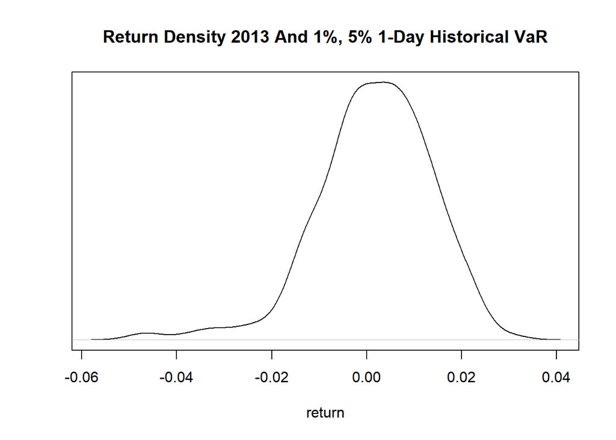

```r
ret.d = density(crsp.ew$ret)
plot(ret.d,
     xlab='return',
     ylab="",
     yaxt='n',
     main='Return Density 2013 And 1%, 5% 1-Day Historical VaR')
```

- - The estimates of the 1% and 5% 1-Day Historical VaR

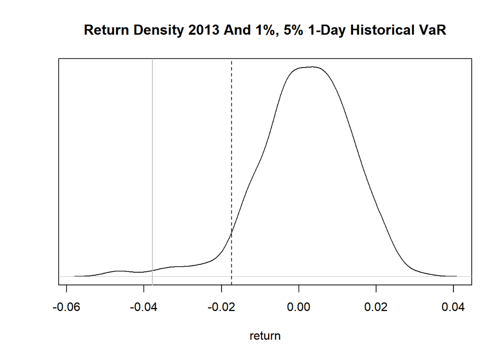

```r
ret.d = density(crsp.ew$ret)
plot(ret.d,
     xlab='return',
     ylab="",
     yaxt='n',
     main='Return Density 2013 And 1%, 5% 1-Day Historical VaR')
abline(v=-var.hist.q1/invest,col="gray",lty=1)
abline(v=-var.hist.q5/invest,col="black",lty=2)
```

- - The normal distribution of returns based on the mean and standard deviation of portfolio
  - First, we create a sequence of 1000 numbers between the smallest and largest returns.
  - This creates bounds for the normal density plot that follows.
  - Then, we use the dnorm command to provide the values of the probability density function for the normal distribution.
  - The dnorm command takes on three arguments.
  - The first argument uses the x vector we created above.
  - The second argument is the mean of the returns.
  - The third argument is the standard deviation of the returns

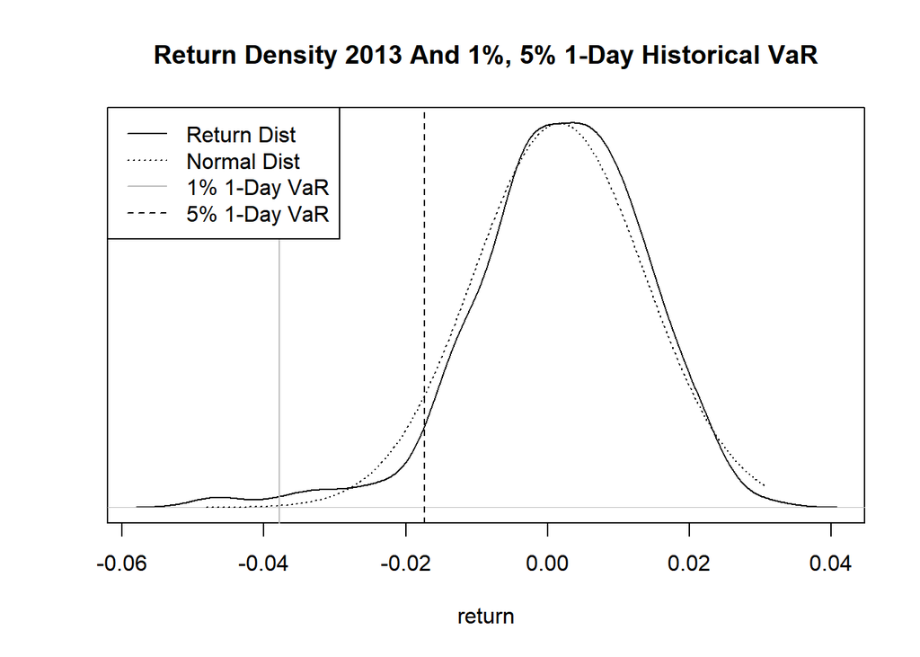

```r
ret.d = density(crsp.ew$ret)
plot(ret.d,
     xlab='return',
     ylab="",
     yaxt='n',
     main='Return Density 2013 And 1%, 5% 1-Day Historical VaR')

abline(v=-var.hist.q1/invest,col="gray",lty=1)
abline(v=-var.hist.q5/invest,col="black",lty=2)

x = seq(min(crsp.ew$ret),max(crsp.ew$ret),length=1000)
y = dnorm(x,mu,sigma)
lines(x,y,type="l",col="black",lwd=1,lty=3)

legend("topleft",
       c("Return Dist",
         "Normal Dist",
         "1% 1-Day VaR",
         "5% 1-Day VaR"),
       col=c("black","black","gray","black"),
       lty=c(1,3,1,2))
```

# Gaussian ES Example

- Step 1: Use “crsp.ew.RData” and filter data to 2013.

```r
load("crsp.ew.RData")
head(crsp.ew)
```

```
##         date       ew    yymm          ret   ew.all
## 1 2010-01-04 1.019541 2010-01 0.0195410781 1.019541
## 2 2010-01-05 1.031180 2010-01 0.0114163006 1.031180
## 3 2010-01-06 1.042768 2010-01 0.0112376086 1.042768
## 4 2010-01-07 1.052241 2010-01 0.0090844033 1.052241
## 5 2010-01-08 1.060328 2010-01 0.0076855758 1.060328
## 6 2010-01-11 1.061044 2010-01 0.0006743764 1.061044
```

```r
crsp.ew = crsp.ew[which(substr(crsp.ew$date,1,4)=='2013'),
                  c("date","ret")]
head(crsp.ew)
```

```
##           date         ret
## 755 2013-01-02 0.022294022
## 756 2013-01-03 0.017951026
## 757 2013-01-04 0.021527329
## 758 2013-01-07 0.014202149
## 759 2013-01-08 0.004382363
## 760 2013-01-09 0.009990037
```

- Step 2: Calculate the ES at 1% and 5% using the formula
  - Calculate Mean and Standard Deviation of Historical Daily Portfolio Returns

```r
mu = mean(crsp.ew$ret,na.rm=T)
sigma = sd(crsp.ew$ret,na.rm = T)
mu
```

```
## [1] 0.001633032
```

```r
sigma
```

```
## [1] 0.01209905
```

```r
es.q1 = invest * (mu+sigma*dnorm(qnorm(0.01))/0.01)
es.q5 = invest * (mu+sigma*dnorm(qnorm(0.05))/0.05)
print(paste0("ES.q1=",round(es.q1,2)))
```

```
## [1] "ES.q1=33879.59"
```

```r
print(paste0("ES.q5=",round(es.q5,2)))
```

```
## [1] "ES.q5=26589.9"
```

# Historical ES Example

- Step 1: Identify Historical VaR Limit for Portfolio
  - Create variables that hold the historical 1 and 5% VaR estimates.

```r
var.hist.q1
```

```
##       1%
## 37793.41
```

```r
var.hist.q5
```

```
##       5%
## 17344.71
```

- Step 2: Identify Portfolio Losses in Excess of VaR
  - Use dummy variables to indicate what returns fall short of the threshold for 1 and 5% Historical ES.
  - Use which function and base R syntax

```r
crsp.ew$pl = crsp.ew$ret * invest
crsp.ew$dummy.q1=NA
crsp.ew$dummy.q5=NA
crsp.ew[which(crsp.ew$pl<=(-var.hist.q1)),]$dummy.q1=1
crsp.ew[which(crsp.ew$pl<=(-var.hist.q5)),]$dummy.q5=1
```

- Step 3: Compute Average of Losses in Excess of VaR

```r
crsp.ew$es.q1 = -crsp.ew$dummy.q1 * crsp.ew$pl
crsp.ew$es.q5 = -crsp.ew$dummy.q5 * crsp.ew$pl

es.hist.q1 = mean(crsp.ew$es.q1,na.rm=T)
es.hist.q5 = mean(crsp.ew$es.q5,na.rm=T)

cat("Historical ES 0.01 = ",round(es.hist.q1,2),"\n")
```

```
## Historical ES 0.01 =  43602.08
```

```r
cat("Historical ES 0.05 = ",round(es.hist.q5,2),"\n")
```

```
## Historical ES 0.05 =  28908.45
```

# Summarise VaR and ES

```r
var.g = c(var.q1,var.q5)
var.h = c(var.hist.q1,var.hist.q5)
es.g = c(es.q1,es.q5)
es.h = c(es.hist.q1,es.hist.q5)
risk.tb = cbind(var.g,es.g,var.h,es.h)
risk.tb
```

```
##       var.g     es.g    var.h     es.h
## 1% 26513.57 33879.59 37793.41 43602.08
## 5% 18268.14 26589.90 17344.71 28908.45
```